# 2-Way ANOVA

Practice using dplyr to summarise data; ggplot2 to make visualization. Use the built-in CO2 dataset; don’t need to load any library to access. **Ignore that data are repeated sample of a handful of individual plants.**

```r
library(dplyr)
library(ggplot2)
library(emmeans)
```

**CO2 Example**

```r
#find out more information about the CO2 dataset (built into R)
?CO2
```

Details

The CO2 uptake of six plants from Quebec and six plants from Mississippi was measured at several levels of ambient CO2 concentration. Half the plants of each type were chilled overnight before the experiment was conducted.

Source

Potvin, C., Lechowicz, M. J. and Tardif, S. (1990) “The statistical analysis of ecophysiological response curves obtained from experiments involving repeated measures”, Ecology, 71, 1389–1400.

Pinheiro, J. C. and Bates, D. M. (2000) Mixed-effects Models in S and S-PLUS, Springer.

```r
data<-CO2
```

```r
summary_data<-data %>%
  group_by(Type, Treatment) %>%
  summarise(
    mean_uptake=mean(uptake),
    sd_uptake=sd(uptake),
    n=n(),
    se_uptake=sd(uptake)/sqrt(n)
  )
summary_data
```

| Type | Treatment | mean_uptake | sd_uptake | n | se_uptake |
| --- | --- | --- | --- | --- | --- |
| Quebec | nonchilled | 35.33333 | 9.596371 | 21 | 2.0940998 |
| Quebec | chilled | 31.75238 | 9.644823 | 21 | 2.1046730 |
| Mississippi | nonchilled | 25.95238 | 7.402136 | 21 | 1.6152785 |
| Mississippi | chilled | 15.81429 | 4.058976 | 21 | 0.8857412 |

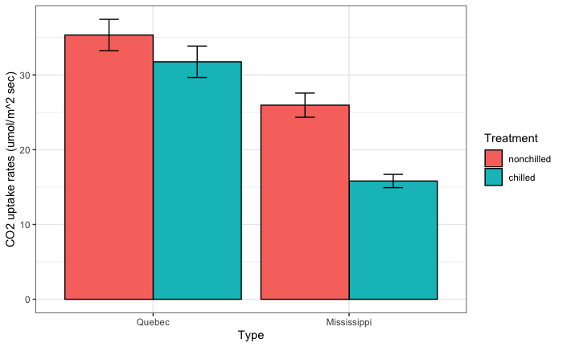

```r
ggplot(summary_data, aes(x=Type, y=mean_uptake, fill=Treatment)) +
  geom_bar(stat="identity", color="black", position=position_dodge()) +
  geom_errorbar(aes(ymin=mean_uptake-se_uptake, ymax=mean_uptake+se_uptake), width=.2, position=position_dodge(.9))+
  ylab("CO2 uptake rates (umol/m^2 sec)")+
  theme_bw()
```

Making this figure is not as intuitive as you might think because of the position dodge required, the stat=“identity”, and error bar specification. Really messes up things; not an intuitive intro example. Note that the reference group in the model summary table is the mean of Quebec non-chilled. Everything else is in reference to that.

```r
model1 <- lm(uptake~Type*Treatment, data=data)
anova(model1)
```

```
Analysis of Variance Table

Response: uptake
               Df Sum Sq Mean Sq F value    Pr(>F)
Type            1 3365.5  3365.5 52.5086 2.378e-10 ***
Treatment       1  988.1   988.1 15.4164 0.0001817 ***
Type:Treatment  1  225.7   225.7  3.5218 0.0642128 .
Residuals      80 5127.6    64.1
---
Signif. codes:  0 ‘***’ 0.001 ‘**’ 0.01 ‘*’ 0.05 ‘.’ 0.1 ‘ ’ 1
```

```r
summary(model1)
```

```
Call:
lm(formula = uptake ~ Type * Treatment, data = data)

Residuals:
    Min      1Q  Median      3Q     Max
-22.452  -3.624   2.167   5.773  10.648

Coefficients:
                                 Estimate Std. Error t value Pr(>|t|)
(Intercept)                        35.333      1.747  20.225  < 2e-16 ***
TypeMississippi                    -9.381      2.471  -3.797 0.000284 ***
Treatmentchilled                   -3.581      2.471  -1.449 0.151141
TypeMississippi:Treatmentchilled   -6.557      3.494  -1.877 0.064213 .
---
Signif. codes:  0 ‘***’ 0.001 ‘**’ 0.01 ‘*’ 0.05 ‘.’ 0.1 ‘ ’ 1

Residual standard error: 8.006 on 80 degrees of freedom
Multiple R-squared:  0.4718,    Adjusted R-squared:  0.452
F-statistic: 23.82 on 3 and 80 DF,  p-value: 4.106e-11
```

```r
#Multiple Contrasts using EMmeans package
emm_model1<- emmeans(model1, "Type", "Treatment")
pairs(emm_model1)
```

```
Treatment = nonchilled:
 contrast             estimate   SE df t.ratio p.value
 Quebec - Mississippi     9.38 2.47 80 3.797   0.0003

Treatment = chilled:
 contrast             estimate   SE df t.ratio p.value
 Quebec - Mississippi    15.94 2.47 80 6.451   <.0001
```

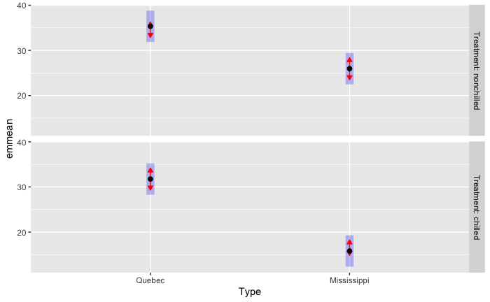

```r
#visually compare marginal means (LS means)
plot(emm_model1, comparisons = TRUE)+
  coord_flip()
```

Because there are two treatments, it breaks them into two panels.

```r
#connecting letters differences report
multcomp::cld(emm_model1)
```

```
Treatment = nonchilled:
 Type        emmean   SE df lower.CL upper.CL .group
 Mississippi   26.0 1.75 80     22.5     29.4  1
 Quebec        35.3 1.75 80     31.9     38.8   2

Treatment = chilled:
 Type        emmean   SE df lower.CL upper.CL .group
 Mississippi   15.8 1.75 80     12.3     19.3  1
 Quebec        31.8 1.75 80     28.3     35.2   2

Confidence level used: 0.95
significance level used: alpha = 0.05
```

Simple Contrasts

```r
contrast(emm_model1, "consec", simple = "each", combine = TRUE, adjust = "mvt")
```

```
 Treatment  Type        contrast             estimate   SE df t.ratio p.value
 nonchilled .           Mississippi - Quebec    -9.38 2.47 80 -3.797  0.0011
 chilled    .           Mississippi - Quebec   -15.94 2.47 80 -6.451  <.0001
 .          Quebec      chilled - nonchilled    -3.58 2.47 80 -1.449  0.4094
 .          Mississippi chilled - nonchilled   -10.14 2.47 80 -4.103  0.0004

P value adjustment: mvt method for 4 tests
```

Pairwise P-value plots; pwpp plots

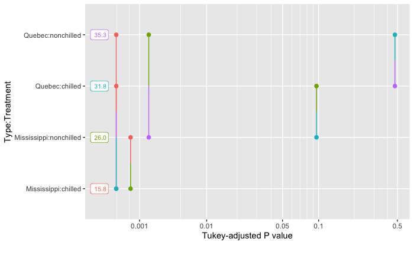

```r
model.cells <- emmeans(model1, ~ Type * Treatment)
pwpp(model.cells, type = "response")
```